# TravToEd_queries

Chad Kakau: 300212228

2024-12-19

Use this document to retrieve census data from the Aotearoa Data Explorer site and import for analysis without downloading a file. The Aotearoa Data Explorer API page provides for a range of query types, for retrieving data we will use:

- GET data queries, or
- GET data by the key

There are other queries that could be used for creating an interface that allows users to select their own filters and outputs:

- GET Data availability
- GET information about data availability

# 1 General process:

1. retrieve API query structure
2. GET information about available data
3. GET ‘travel to education’ data
4. Fit a range of models to data
5. Interpret the different models 2

# 2 Retrieve the API query structure

The Aotearoa Data Explorer API page provides guidance on creating queries for accessing data. Developers must provide authentication and this created quickly by providing a valid email [(instructions here)](https://portal.apis.stats.govt.nz/documentation). The Aotearoa Data Explorer API provides a range of queries and allows developers to test queries online to understand the structure and format of the responses. This document focusses on two queries that will help determine the key dimensions and levels available for access, which can be used to query the database for specific data sets by filtering those dimensions:

- **GET information about data availability** takes the form:

  GET “[https://apis.stats.govt.nz/ade-api/rest/availableconstraint/{flowRef}/{key}](https://apis.stats.govt.nz/ade-api/rest/availableconstraint/%7BflowRef%7D/%7Bkey%7D)”
- **GET data by key** takes the form:

  “GET [http://apis.stats/govt.nz/ade-api/rest/data/{flowRef}/{key}](http://apis.stats/govt.nz/ade-api/rest/data/%7BflowRef%7D/%7Bkey%7D)[?dimenstionAtObservation][&detail][&includeHistory]”

# 3 GET information about data availability

We can first use the “httr2” package to access the Aotearoa Data Explorer API and call the “GET information about Data availability” query to determine relevant data keys. The “httr2” provides a range of tools for interacting with APIs including constructing, validating, and sending requests, handling responses and managing a range of standard API actions.

The “travel to education” data is part of the Statistics New Zealand framework, as resourceId: CEN23_TRA_001 (the ‘transport’ concept within the census 2023 data). To give helpful context to the “travel to education” data, additional dimensions, or “components” are defined and each component includes individual levels (e.g. “walk or jog”, “bicycle”, etc.) and aggregations (e.g. “total”, “median”). The key dimensions relating to the “travel to education” concept are:

- CEN23_YEAR_001: census year
- CEN23_TED_002: main means of travel
- CEN23_AGE_003: age category (available at 5-year groupings)
- CEN23_GEN_002: gender category
- CEN23_EDU_001: location by educational institution address

For this initial example, we will make a “GET information about data availability” request to the Aotearoa Data Explorer API. The request takes the form:

- GET “[https://apis.stats.govt.nz/ade-api/rest/availableconstraint/{flowRef}/{key}](https://apis.stats.govt.nz/ade-api/rest/availableconstraint/%7BflowRef%7D/%7Bkey%7D)”

with the following parameter values:

Parameters for other queries could include:

- context: “dataflow”
- agencyId: “STATSNZ”
- resourceId: “CEN23_TRA_001”
- version: “1.0”
- key: “2023”
- componentId: “CEN23_YEAR_001,CEN23_TED_002,CEN23_AGE_003,CEN23_GEN_002”

The Aotearoa Date Explorer API requires other information, including authentication and output format, so these are included when constructing the request.

```r
# check availability for data from the Census 2023 Transport concept.
#The GET Data availability query has the format:
# GET https://apis.stats.govt.nz/ade-api/rest/v2/availability/{context}/{agencyId}/{resourceId}/{version}/{key}/{componentId}

# load libraries for API queries, message handling, and data transformations
library(httr2) # interact with api
library(xml2) # handle xml nodes and data
library(purrr) # pluck function
library(dplyr) # glimpse function

# create base path
base_path <- request("https://apis.stats.govt.nz/ade-api/rest") %>%
  req_headers(
    `Ocp-Apim-Subscription-Key`= authKey,
    .redact = "Ocp-Apim-Subscription-Key",
    `Cache-Control` = 'no-cache',
    `accept-encoding` = 'identity'
  )
```

Using the “httr2” package in R we can construct and preview the request to check the structure and then send the request to the server.

```r
# GET "https://apis.stats.govt.nz/ade-api/rest/availableconstraint/{flowRef}/{key}"

# set parameters
flowRef <- "CEN23_TRA_001"
key <- "all"

# construct request
data_info_req <- base_path |>
  req_url_path_append("availableconstraint") |>
  req_url_path_append(flowRef) |>
  req_url_path_append(key) |>
  req_url_query(
    mode = "exact",
    references = "codelist") |>
  req_headers(
    `content-language`="en,en-NZ",
    encoding = "UTF-8"
  )

# preview the request
req_dry_run(data_info_req)
```

```
## GET /ade-api/rest/availableconstraint/CEN23_TRA_001/all?mode=exact&references=codelist HTTP/1.1
## Host: apis.stats.govt.nz
## User-Agent: httr2/1.1.0 r-curl/6.1.0 libcurl/8.10.1
## Accept: */*
## Ocp-Apim-Subscription-Key: <REDACTED>
## Cache-Control: no-cache
## accept-encoding: identity
## content-language: en,en-NZ
## encoding: UTF-8
```

```r
# perform request
data_info_resp <- req_perform(data_info_req)
```

We need to extract the relevant information from the response and can draw on the “xml2” package to handle the response. Since we are interested in identifying the relevant levels within each dimension we extract the name of each dimension (e.g. year, Age etc.) and the name and numeric code for each level within the dimension. We can use the codes to build more focussed queries and to organise data in the responses.

Using the “purrr” package within R, we can extract the relevant information and construct objects for holding the information.

From this query we can extract the available dimensions of the travel to education data set:

| CL | dimension |
| --- | --- |
| CEN23_AGE_003 | Age |
| CEN23_EDU_001 | Educational institution address |
| CEN23_GEN_002 | Gender |
| CEN23_TED_002 | Main means of travel to education |
| CEN23_YEAR_001 | Census Year |

We can preview the decoded Travel to Education levels within each dimension and view the first few entries within each:

**CEN23_AGE_003, Age**:

The “Age” dimension has 25 levels and includes a range of groupings and aggregations that can be accessed by specific codes. The total across all age groups can be accessed with code “99”. Single-digit codes 1, 2, 3, 4 access age groups “Under 15”, “15-29 years”, “30-64 years”, and “65 years and over” age groups, respectively. Responses aggregated into five year groupings can be accessed using double digit codes (i.e. 01 to 19). The median response across all groups can be accessed with the code “Median”:

| level | code |
| --- | --- |
| Total - age | 99 |
| Under 15 years | 1 |
| 15-29 years | 2 |
| 30-64 years | 3 |
| 65 years and over | 4 |
| 0-4 years | 01 |
| 5-9 years | 02 |
| 10-14 years | 03 |
| 15-19 years | 04 |
| 20-24 years | 05 |

**CEN23_EDU_001, Educational institution address**:

| level | code |
| --- | --- |
| Total - New Zealand by regional council | 9999 |
| Total - New Zealand by territorial authority and Auckland local board/SA2 | 999999 |
| Northland Region | 01 |
| Auckland Region | 02 |
| Waikato Region | 03 |
| Bay of Plenty Region | 04 |
| Gisborne Region | 05 |

Responses for territorial Authorities can be accessed with three digit codes.

| level | code |
| --- | --- |
| Far North District | 001 |
| Whangarei District | 002 |
| Kaipara District | 003 |
| Auckland | 076 |
| Thames-Coromandel District | 011 |

And responses for individual Statistical Area 2 can be accessed with six-digit codes.

| level | code |
| --- | --- |
| North Cape | 100100 |
| Rangaunu Harbour | 100200 |
| Inlets Far North District | 100301 |
| Karikari Peninsula | 100400 |
| Tangonge | 100500 |

The data also includes selectors for responses that don’t fit into any geographical categorisation, such as “Response unidentifiable” (code “77”), “Overseas” (code “88”), “No Fixed Address” (code “96”) etc.

| level | code |
| --- | --- |
| Response Unidentifiable | 77 |
| Overseas | 88 |
| No Fixed Address | 96 |
| Not Stated | 97 |
| New Zealand not further defined | 98 |
| Area Outside Region | 99 |

**CEN23_GEN_002, Gender**:

The “Gender” dimension has 4 levels that include “Total - gender” (code “99”), “Male/Tane”, “Female/Wahine”, and “Another gender/He ira kē anō” (codes “1”, “2”, and “3” respectively).

| level | code |
| --- | --- |
| Total - gender | 99 |
| Male / Tāne | 1 |
| Female / Wahine | 2 |
| Another gender / He ira kē anō | 3 |

**CEN23_TED_002, Main means of travel to education**:

The “Main means of travel to education” dimension has 13 levels that can be accessed with three digit codes, and includes aggregations of “Total - main means of travel to education” (code “9999”), “Total stated - main means of travel to education” (code “7777”) and “Not elsewhere included” (code “999”):

| level | code |
| --- | --- |
| Total - main means of travel to education | 9999 |
| Total stated - main means of travel to education | 7777 |
| Not elsewhere included | 999 |
| Study at home | 001 |
| Drive a car, truck or van | 002 |
| Passenger in a car, truck or van | 003 |

**CEN23_YEAR_001, Census Year**:

The “Census Year” dimension has 2 levels that are accessed by entering their values as four digit character strings:

| level | code |
| --- | --- |
| 2018 | 2018 |
| 2023 | 2023 |

# 4 **‘GET data by key’** query

Now knowing the individual codes for different levels, We can construct an API request for “travel to education” data by selecting individual levels of key dimensions and totals of other dimensions. For instance to retrieve counts for individual means of travel over different years, we include the individual levels for “Year” (“2018+2023”) and the individual levels for “main means of travel” (“010+009+008+007+006+005+004+003+002+001”), with totals for the other dimensions - “Educational institution” (9999), “Age” (“99”), “Gender” (“99”).

- CEN23_YEAR_001: “2018+2023”
- CEN23_TED_002: “010+009+008+007+006+005+004+003+002+001”
- CEN23_EDU_001: “9999”
- CEN23_AGE_003: “99”
- CEN23_GEN_002: “99”

The request takes the format:

- “GET [http://apis.stats/govt.nz/ade-api/rest/data'/{flowRef}/{key}](http://apis.stats/govt.nz/ade-api/rest/data'/%7BflowRef%7D/%7Bkey%7D)[?dimenstionAtObservation][&detail][&includeHistory]”
- Parameters:
  - flowRef: “STATSNZ,CEN23_TRA_001,1.0”
  - key: “2018+2023.9999.010+009+008+007+006+005+004+003+002+001.99.99”
  - format: “csv”
  - detail: “full”

We can check the structure of the request and send to the API.

We requested data in csv format so the API organises the response in a reasonably well-structured way that we can easily access (using “httr2”) and convert (using “readr” and “dplyr” packages in R). We initially extract the data as a tibble data frame …

| CEN23_YEAR_001 | CEN23_TED_002 | OBS_VALUE |
| --- | --- | --- |
| 2018 | Study at home | 61686 |
| 2018 | Drive a car, truck or van | 128211 |
| 2018 | Passenger in a car, truck or van | 449556 |
| 2018 | Bicycle | 41445 |
| 2018 | Walk or jog | 235806 |
| 2018 | School bus | 113400 |
| 2018 | Public bus | 82149 |
| 2018 | Train | 21864 |
| 2018 | Ferry | 1548 |
| 2018 | Other | 15171 |
| 2023 | Study at home | 99258 |
| 2023 | Drive a car, truck or van | 124935 |
| 2023 | Passenger in a car, truck or van | 489279 |
| 2023 | Bicycle | 42474 |
| 2023 | Walk or jog | 213957 |
| 2023 | School bus | 112770 |
| 2023 | Public bus | 82683 |
| 2023 | Train | 17811 |
| 2023 | Ferry | 1242 |
| 2023 | Other | 15318 |

… and create a contingency to more efficiently review the counts (“OBS_VALUE”) by categories (“CEN23_TED_002”, “CEN23_YEAR_001”).

|  | 2018 | 2023 |
| --- | --- | --- |
| Bicycle | 41445 | 42474 |
| Drive a car, truck or van | 128211 | 124935 |
| Ferry | 1548 | 1242 |
| Other | 15171 | 15318 |
| Passenger in a car, truck or van | 449556 | 489279 |
| Public bus | 82149 | 82683 |
| School bus | 113400 | 112770 |
| Study at home | 61686 | 99258 |
| Train | 21864 | 17811 |
| Walk or jog | 235806 | 213957 |

Before doing any more detailed analysis and to make data retrieval easier, we create functions that access the Aotearoa Data Explorer API, extract relevant data and format the data in structured data frames.

# 5 Do some exploratory analysis

In order to conduct exploratory analysis, we first retrieve the data from the API, review each predictor variable in relation to the count of responses, and then conduct review of pairs of predictor variables. Initial analysis is conducted using three visual plots. The “break-down by year” plot shows the count of each level in the variable for 2018 and 2023. This plot shows the absolute counts for each level and can be used to identify the levels that are most “important” (i.e. highest count). For greater insight into the change between 2018 and 2023, two additional plots show “absolute-change” and “percent-change”. The “absolute-change” chart provides a direct measure of the total quantity of change between 2018 and 2023. The “percent-change” chart quantifies change between 2018 and 2023 as a proportion of the 2018 count. This ratio of change allows for comparison between categories that may be measured on different scales.

We will first retrieve the data with the following predictors:

- Age: “Under 15 years”, “15-29 years”, “30-64 years”, “65 years and over”
- Year: “2018”, “2023”
- Gender: “Male/Tāne”, “Female/Wahine”, “Another gender / He ira kē anō”
- Main means of travel: all means of travel

Initial exploratory analysis will be conducted using visual plots and will focus first on individual predictors with the response variable (count), followed by analysis of pairs of predictors with the response variable.

## 5.1 One predictor and the response variable

Review each predictor against the response variable using totals (by year), total change and percent change (between years) for each level of the predictor.

### 5.1.1 Main means of travel to education

The main dimension of interest in this study is the “main means of travel to education” dimension, which counts the number of times different means of travel are used for travelling to the respondents place of education. The dimension has several levels:

| YEAR | total |
| --- | --- |
| 2018 | 1148127 |
| 2023 | 1187763 |

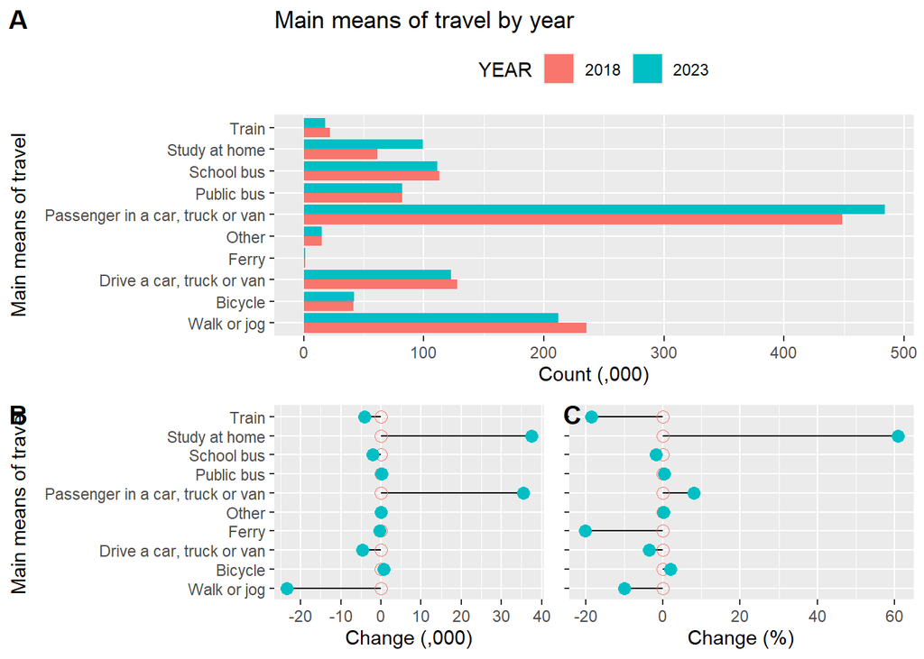

Figure 5.1: Total and changes in ‘Main means of travel’ for 2018 and 2023

Figure 5.1 A shows that “Passenger in a car, truck or van” had the highest count over both 2018 and 2023, followed by “Walk or jog”, “Drive a car, truck, or van”, “School bus” then “Public bus”, “Study at home”, and “Bicycle”. The categories “Train”, “Ferry” and “Other” have low counts, that are consistent between both years. Figure 5.1 B shows the two categories with highest change between 2018 and 2023 were “Study at home” (increasing by around 38,000) and “Passenger in a car, truck or van” (increasing by around 35,000). The largest decrease was in category “Walk or jog”, with a reduction of nearly 25,000). Figure 5.1 C shows the highest percent-change increase was for the “Study at home” category (60%), followed by “Passenger in a car, truck or van” at just under 10% increase. The categories with the largest decrease were “Ferry” and “Train”, at around 20% decrease, followed by “Walk or jog” with a decrease of around 10%.

Based on this analysis, we are most interested in “Passenger in a car, truck or van”, “Walk or jog”, as the most popular responses that also had the largest absolute change in counts between 2018 and 2023; and “Study at home” as the highest absolute and percentage change.

### 5.1.2 Age

| AGE | Total |
| --- | --- |
| Under 15 years | 1395048 |
| 15-29 years | 700146 |
| 30-64 years | 228843 |
| 65 years and over | 11853 |

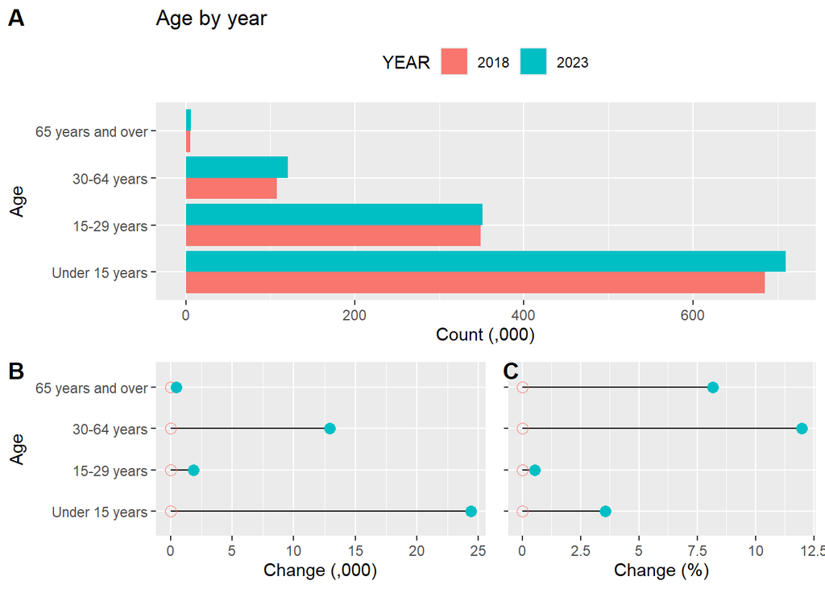

Figure 5.2: Total and changes in ‘Age’ for 2018 and 2023

Figure 5.2 A shows that most respondents were in the “Under 15 years” category, followed by the “15-29 years” category, then “30-64 years” and finally the “65 years and over” category. All categories increased between 2018 and 2023. Figure 5.2 B shows the largest absolute increase was in the “Under 15 years” category, increasing by just under 25,000, followed by 12,000 increase for “30-64 years” then “15-29 years”. Figure 5.2 C shows the highest percentage change was in the “30-64 years” category, increasing by nearly 12%, followed by the “65 years and over” category, and then an increase of 3.5% for the “Under 15 years” category.

The most important age groups are “Under 15 years” with the highest total count and absolute change. Although containing fewer respondents in total, the “30-64 years” category has the highest percentage change, and second highest increase overall.

### 5.1.3 Educational institute by address (region)

| EDU | Total |
| --- | --- |
| Northland Region | 80616 |
| Auckland Region | 825822 |
| Waikato Region | 226152 |
| Bay of Plenty Region | 140664 |
| Gisborne Region | 24384 |
| Hawke’s Bay Region | 77712 |
| Taranaki Region | 54636 |
| Manawatū-Whanganui Region | 115326 |
| Wellington Region | 254424 |
| West Coast Region | 11847 |
| Canterbury Region | 295701 |
| Otago Region | 120537 |
| Southland Region | 44703 |
| Tasman Region | 20892 |
| Nelson Region | 24519 |
| Marlborough Region | 17955 |

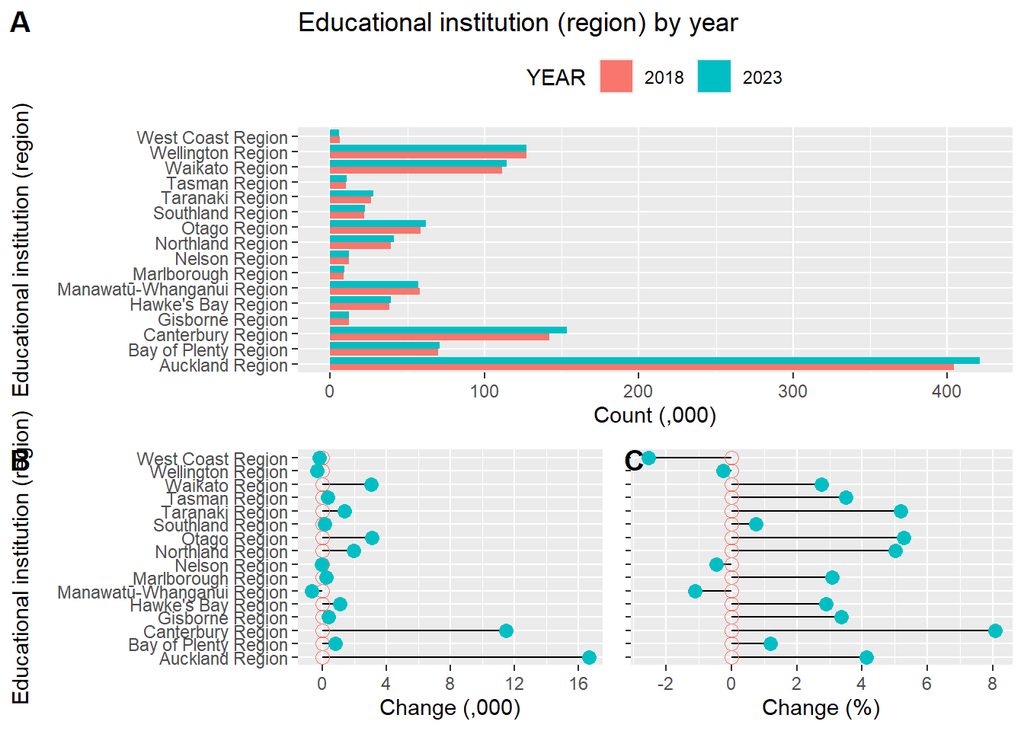

Figure 5.3: Total and changes in ‘Educational institute location (region)’ for 2018 and 2023

Figure 5.3 A shows that the highest number of responses were in the “Auckland Region”, with a count over 800,000, followed by “Canterbury Region”, “Wellington Region”, then “Waikato Region”. Figure 5.3 B shows the largest total increase was in “Auckland Region” (over 16,000), then “Canterbury Region” (nearly 12,000 increase), and then “Otago Region” and “Waikato Region”, both with increases of around 3,000. Figure 5.3 C shows “Canterbury Region” has the highest percent-change at 8%, followed by “Otago Region”, “Taranaki Region”, and “Northland Region”, all at, or just over 5%.

The most important categories in the Educational institution address (region) dimension are “Auckland Region” with the highest total count and total change between 2018 and 2023, “Canterbury Region” as second highest total count, total change and highest percentage change between 2018 and 2023. “Wellington Region” has the next highest total, althrough a relatively small change between census years. “Waikato Region” has the next highest total, and along with “Otago Region” , have the third and fourth highest total change between census years.

### 5.1.4 Gender

| GEN | Total |
| --- | --- |
| Male / Tāne | 1128981 |
| Female / Wahine | 1199703 |
| Another gender / He ira kē anō | 7206 |

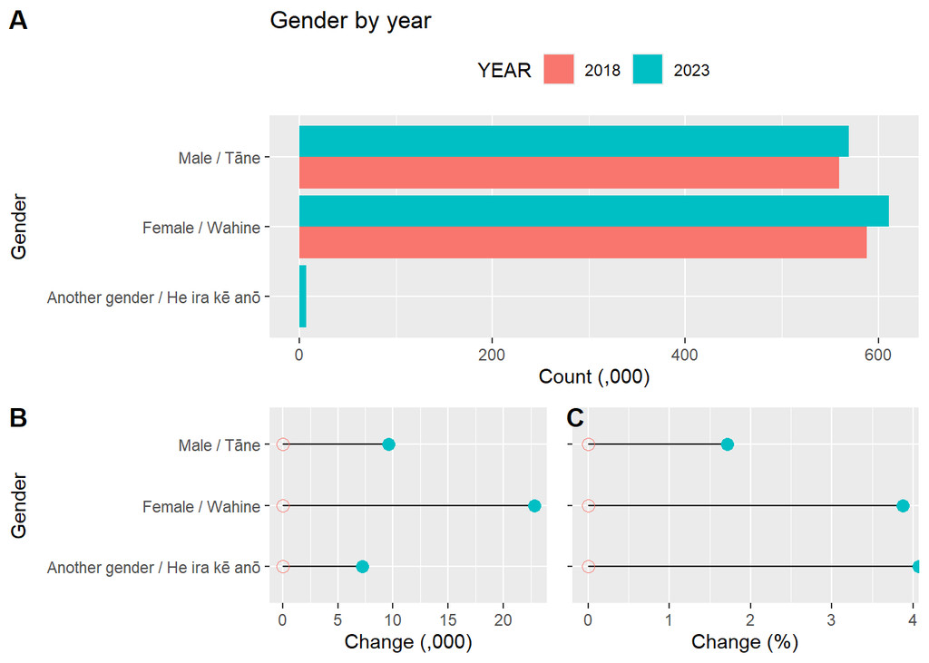

Figure 5.4: Total and changes in ‘Gender’ for 2018 and 2023

“Gender” was added as a new concept in the 2023 census, prior to that, the concept of sex at birth was used. That means there is no 2018 data to compare the gender level “Another gender / He ira kē anō”, so changes assume an initial count of zero.

Figure 5.4 A shows “Female/Wahine” has the highest total across both years, followed by “Male/Tāne”. “Another gender / He ira kē anō” has the lowest count. Figure 5.4 B shows the greatest total change for “Female / Wahine” (increase of over 22,500), “Male / Tāne” increased by just under 10,000 and then “Another gender / He ira kē anō” with an increase of close to 7,500. Figure 5.4 C shows “Another gender / He ira kē anō” has the highest percent-change at just over 4%, followed by “Female / Wahine” at just under 4% and then “Male / Tāne” with an increase of 1.5%.

## 5.2 Paired predictors and the response variable

Review each pair of predictors against the response variable using totals (by year), total change and percent change (between years) for each level of the predictor.

### 5.2.1 Main means of travel by major age groups

| TED | Under 15 years | 15-29 years | 30-64 years | 65 years and over |
| --- | --- | --- | --- | --- |
| Study at home | 13902 | 53775 | 89841 | 3402 |
| Drive a car, truck or van | 0 | 149355 | 95712 | 5508 |
| Passenger in a car, truck or van | 817836 | 107325 | 6315 | 627 |
| Bicycle | 59580 | 19794 | 3945 | 213 |
| Walk or jog | 279807 | 155811 | 11235 | 696 |
| School bus | 161034 | 62424 | 657 | 75 |
| Public bus | 38370 | 110847 | 14178 | 984 |
| Train | 7635 | 28611 | 3258 | 138 |
| Ferry | 318 | 1977 | 438 | 39 |
| Other | 16566 | 10227 | 3264 | 171 |

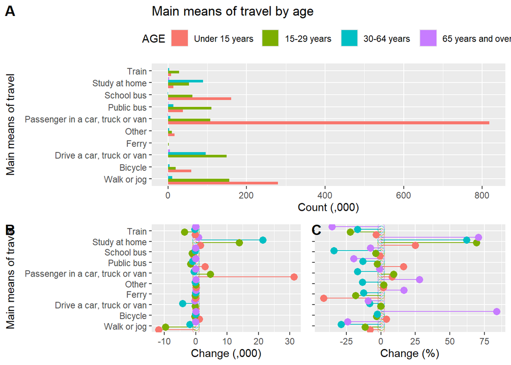

Figure 5.5: Total and changes in ‘Main means of travel’ and ‘Age’ for 2018 and 2023

Figure 5.5 A shows that “Under 15 years” dominates the totals, followed by “15-29 years”, then “30-64 years”. For the “Under 15 years” dimension, “Passenger in a car, truck or van” has by far the highest count, followed by “Walk or jog”, “School bus”, and then “Bicycle”. For the “15-29 years” age group, “Walk or jog” has the highest count, followed by “Drive a car, truck or van”, then “Public bus” and “Passenger in a car, truck or van”, followed by “School bus” and “Study at home”. For the “30-64 years” age group, “Drive a car, truck or van” has the highest count, followed by “Study at home”.

Figure 5.5 B shows that “Under 15 years” age group has largest total change for “Passenger in a car, truck or van” (increase over 30,000), and “Walk or jog” (decrease just over 10,000). The “15-29 years” age group has largest total change for “Study at home” (increase of nearly 15,000), “Walk or jog” (decrease of nearly 10,000) and a small increase of just under 5,000 for “Passenger in a car, truck or van”. The “30-64 years” age group had largest total change for “Study at home” (increase over 20,000), and a decrease of nearly 5,000 for “Drive a car, truck or van”.

This analysis highlights the importance of the “Passenger in a car, truck or van”, “Walk or jog”, “School bus”, and “Bicycle” categories for the “Under 15 years” age group. For the “15-29 years” age group, the most important categories appear to be “Walk or jog”, “Passenger in a car, truck or van”, and “Study at home”. For the “30-64 years” age group, the most important categories appear to be “Drive a car, truck or van”, and “Study at home”. The “65 years and over” age group appears to have little impact on the overall data and could be considered for consolidation with the “30-64 years age group”

### 5.2.2 Main means of travel by gender

| TED | Male / Tāne | Female / Wahine | Another gender / He ira kē anō |
| --- | --- | --- | --- |
| Study at home | 54306 | 105801 | 813 |
| Drive a car, truck or van | 111213 | 138633 | 729 |
| Passenger in a car, truck or van | 458517 | 472014 | 1572 |
| Bicycle | 59463 | 23781 | 288 |
| Walk or jog | 220242 | 225702 | 1605 |
| School bus | 112770 | 110853 | 567 |
| Public bus | 73530 | 89523 | 1326 |
| Train | 19326 | 20130 | 186 |
| Ferry | 1419 | 1332 | 21 |
| Other | 18195 | 11934 | 99 |

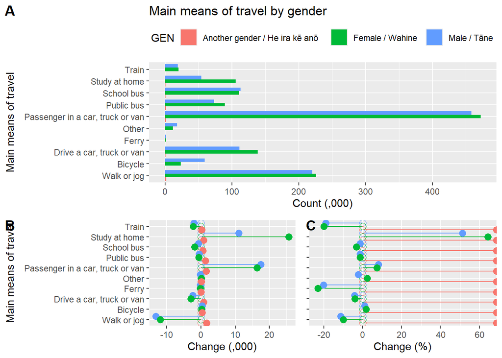

Figure 5.6: Total and changes in ‘Main means of travel’ and ‘Gender’ for 2018 and 2023

Figure 5.6 B shows “Female / Wahine” have largest change for “Study at home” (increase of more than 25,000), then “Passenger in a car, truck or van” (increase of 15,000), and “Walk or jog” (decrease of 12,000). For “Male / Tāne” the largest change is for “Passenger in a car, truck or van” (increase of more than 16,000), “Walk or jog” (decrease of 13,000), and “Study at home” (increase of just over 10,000). “Another gender / He ira kē anō” had small increases across the board, but again, the quantity of increase is difficult to determine from this plot.

Figure 5.6 C shows “Female / Wahine” have largest percent change for “Study at home” (increase of nearly 65%), around 20% decrease for “Ferry” and “Train”, around 10% decrease for “Walk or jog” and around 8% increase for “Passenger in a car, truck or van”. “Male / Tāne” have largest percent change of 50% increase for “Study at home”, 20% decrease for “Ferry” and “Train”, around 11% decrease for “Walk or jog” and around 8% increase for “Passenger in a car, truck or van”. “Another gender / He ira kē anō” has high percentage change across all methods of travel, reflecting the inability to compute ratio increase from zero.

This analysis highlights the importance of the “Passenger in a car, truck or van” category for both “Female / Wahine” and “Male / Tāne” genders. Similarly the “Walk or jog”, “Study at home” and “Drive a car, truck or van” categories appear to be important for both “Female / Wahine” and “Male / Tāne” genders. Since the gender category “Another gender / He ira kē anō” has no data for 2018 and low counts, it could be consolidated with one of the other gender categories (e.g. “Male / Tāne” & “Another gender / He ira kē anō” to give gender categories: “Female / Wahine” and “Not Female / Wahine”).

### 5.2.3 Main means of travel by educational institution location (region)

| TED | Northland Region | Auckland Region | Waikato Region | Bay of Plenty Region | Gisborne Region | Hawke’s Bay Region | Taranaki Region | Manawatū-Whanganui Region | Wellington Region | West Coast Region | Canterbury Region | Otago Region | Southland Region | Tasman Region | Nelson Region | Marlborough Region |
| --- | --- | --- | --- | --- | --- | --- | --- | --- | --- | --- | --- | --- | --- | --- | --- | --- |
| Study at home | 7116 | 44694 | 16566 | 11028 | 1806 | 6060 | 5214 | 10461 | 19062 | 1404 | 20250 | 8028 | 3219 | 2163 | 1944 | 1905 |
| Drive a car, truck or van | 6570 | 91668 | 27027 | 14691 | 2484 | 7182 | 4395 | 13242 | 19845 | 657 | 39777 | 12408 | 4884 | 1197 | 3261 | 1287 |
| Passenger in a car, truck or van | 36048 | 325587 | 101046 | 59679 | 11745 | 36399 | 25482 | 51480 | 88656 | 4779 | 109944 | 38829 | 18978 | 7746 | 7950 | 7755 |
| Bicycle | 858 | 12654 | 8304 | 7293 | 729 | 3492 | 2214 | 4155 | 7158 | 465 | 23031 | 5019 | 2256 | 1623 | 2559 | 1722 |
| Walk or jog | 8343 | 163116 | 35619 | 19884 | 3399 | 12927 | 8361 | 18822 | 59724 | 2094 | 56883 | 40005 | 6270 | 3690 | 5715 | 2697 |
| School bus | 19647 | 55203 | 25797 | 22359 | 3687 | 8940 | 7248 | 11157 | 19362 | 2307 | 22026 | 10017 | 8199 | 4044 | 1953 | 2244 |
| Public bus | 1383 | 92151 | 9483 | 4215 | 192 | 1551 | 1128 | 4434 | 24492 | 45 | 18876 | 5034 | 432 | 171 | 693 | 99 |
| Train | 27 | 27207 | 78 | 24 | 0 | 15 | 3 | 87 | 12105 | 6 | 39 | 36 | 9 | 0 | 6 | 0 |
| Ferry | 18 | 2457 | 36 | 21 | 3 | 9 | 6 | 9 | 132 | 0 | 51 | 15 | 9 | 3 | 3 | 0 |
| Other | 606 | 11085 | 2196 | 1470 | 339 | 1137 | 585 | 1479 | 3888 | 90 | 4824 | 1146 | 447 | 255 | 435 | 246 |

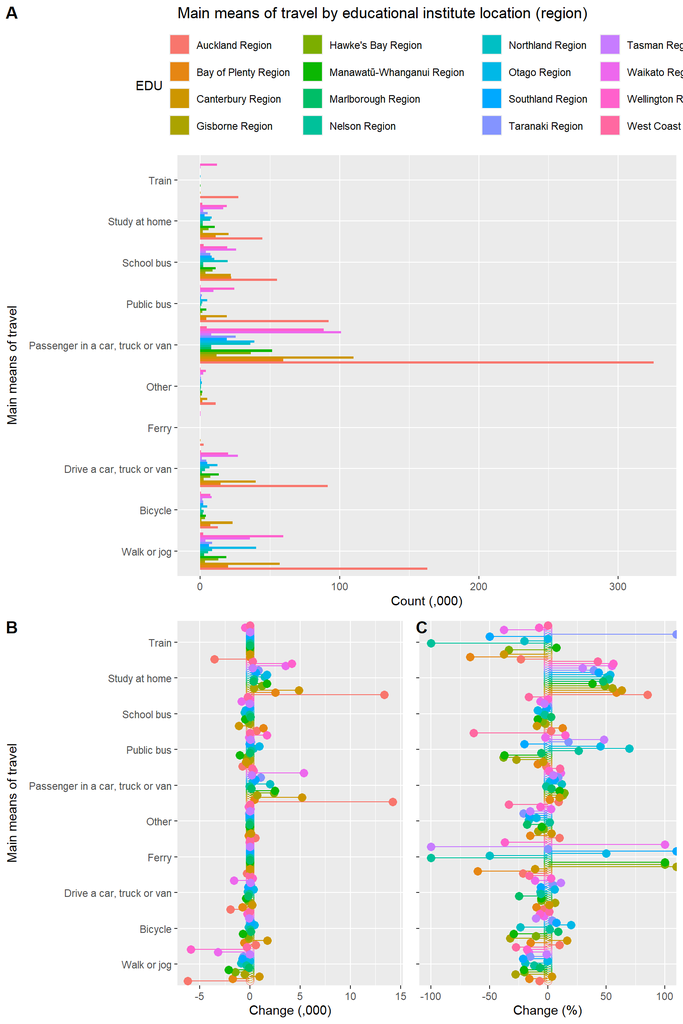

Figure 5.7: Total and changes in ‘Main means of travel’ and ‘Educational institute location (region)’ for 2018 and 2023

Figure 5.7 B is quite cluttered and analysis is difficult, however notable observations include “Auckland Region” has largest changes in “Passenger in a car, truck or van” (increase of nearly 15,000), “Study at home” (increase of nearly 13,000), decreases of nearly 6,000 for “Walk or jog” and around 3,000 for “Train.”Canterbury Region” has largest changes for “Passenger in a car, truck or van” (increase of 5,000), “Study at home” (increase just under 5,000). All regions had an increase in “Study at home” and all regions except “Canterbury region” had a decrease in “Walk or jog”.

Figure 5.7 C is also quite cluttered and the only notable observations reinforce the increase across all regions for the “Study at home” category, and near universal decrease in “Walk or jog”.

## 5.3 Reorganising data

Based on the initial exploratory analysis, we will make some changes to the structure of our data by consolidating some levels. The main regroupings are:

- “Main means of travel”: combine categories “Ferry”, “Train”, “Bicycle”, and “Other”, into a new category called “Other”
- “Gender”: incorporate “Another gender / He ira kē anō” with the “Male / Tāne” category, to give “Female / Wahine” and “Other”
- “Age”: incorporate “30-64 years” and “65 years and over” into a new category called “30 years and over”
- “Educational institute by address (region)”: retain all categories initially, but conduct additional analysis at regional levels and further reduce the “Auckland Region” into Territorial Authorities and Local Boards level.

Reviewing the same plots of paired predictors based on the new data:

### 5.3.1 Main means of travel and age

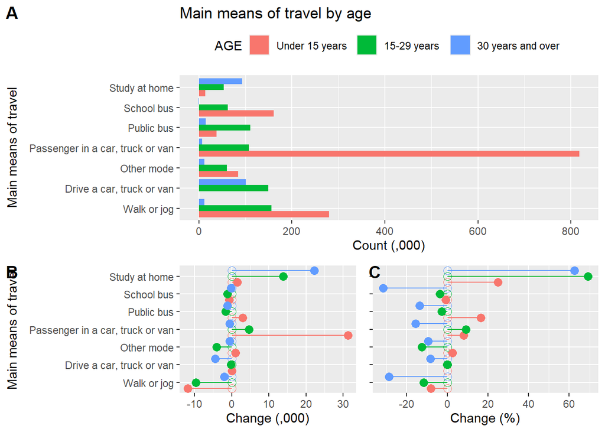

Figure 5.8: Main means of travel by age, reduced age groups and means of travel categories

### 5.3.2 Main means of travel and gender

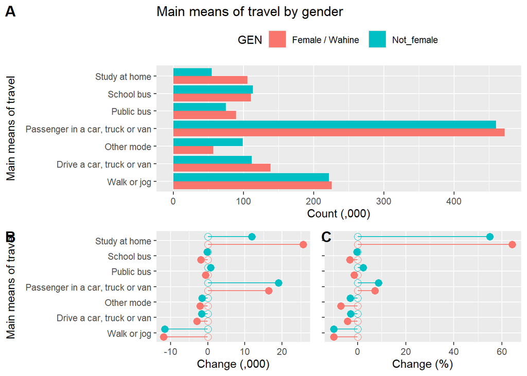

Figure 5.9: Main means of travel by gender, reduced gender and means of travel categories

### 5.3.3 Main means of travel and educational institute location (region)

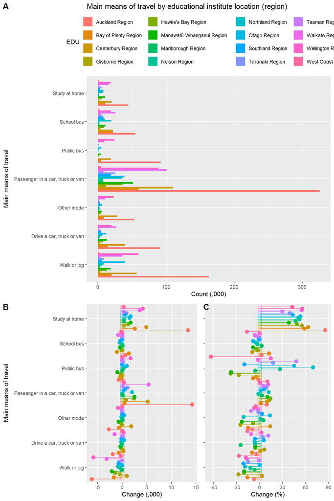

Figure 5.10: Main means of travel by educational institute location, reduced means of travel categories

| YEAR | TED | AGE | Freq |
| --- | --- | --- | --- |
| 2018 | Walk or jog | Under 15 years | 145797 |
| 2023 | Walk or jog | Under 15 years | 134010 |
| 2018 | Drive a car, truck or van | Under 15 years | 0 |
| 2023 | Drive a car, truck or van | Under 15 years | 0 |
| 2018 | Other mode | Under 15 years | 41541 |
| 2023 | Other mode | Under 15 years | 42558 |
| 2018 | Passenger in a car, truck or van | Under 15 years | 393228 |
| 2023 | Passenger in a car, truck or van | Under 15 years | 424608 |
| 2018 | Public bus | Under 15 years | 17727 |
| 2023 | Public bus | Under 15 years | 20643 |
| 2018 | School bus | Under 15 years | 80853 |
| 2023 | School bus | Under 15 years | 80181 |
| 2018 | Study at home | Under 15 years | 6183 |
| 2023 | Study at home | Under 15 years | 7719 |
| 2018 | Walk or jog | 15-29 years | 82713 |
| 2023 | Walk or jog | 15-29 years | 73098 |
| 2018 | Drive a car, truck or van | 15-29 years | 74778 |
| 2023 | Drive a car, truck or van | 15-29 years | 74577 |
| 2018 | Other mode | 15-29 years | 32325 |
| 2023 | Other mode | 15-29 years | 28284 |
| 2018 | Passenger in a car, truck or van | 15-29 years | 51327 |
| 2023 | Passenger in a car, truck or van | 15-29 years | 55998 |
| 2018 | Public bus | 15-29 years | 56223 |
| 2023 | Public bus | 15-29 years | 54624 |
| 2018 | School bus | 15-29 years | 31809 |
| 2023 | School bus | 15-29 years | 30615 |
| 2018 | Study at home | 15-29 years | 19974 |
| 2023 | Study at home | 15-29 years | 33801 |
| 2018 | Walk or jog | 30 years and over | 6969 |
| 2023 | Walk or jog | 30 years and over | 4962 |
| 2018 | Drive a car, truck or van | 30 years and over | 52809 |
| 2023 | Drive a car, truck or van | 30 years and over | 48411 |
| 2018 | Other mode | 30 years and over | 6018 |
| 2023 | Other mode | 30 years and over | 5448 |
| 2018 | Passenger in a car, truck or van | 30 years and over | 3768 |
| 2023 | Passenger in a car, truck or van | 30 years and over | 3174 |
| 2018 | Public bus | 30 years and over | 8136 |
| 2023 | Public bus | 30 years and over | 7026 |
| 2018 | School bus | 30 years and over | 435 |
| 2023 | School bus | 30 years and over | 297 |
| 2018 | Study at home | 30 years and over | 35514 |
| 2023 | Study at home | 30 years and over | 57729 |

# 6 STILL LOTS OF VARIABILITY

Even after consolidating levels of several predictor variables, we are still unable to develop well fitted models. This may be due to a wide range of infrastructure and options for transport across different regions (for instance, almost all of the responses for “Train” were from “Auckland Region” and “Wellington Region”). One approach for reducing the level of variability is to focus on smaller locations that, presumably, share the same infrastructure and modes of transport. With our existing data, we can focus on modelling at individual regional levels, or we can extract new data for smaller regional groups. To do this we can request data from the Aotearoa Data Explorer API that includes (or in our case, focusses on) data at a smaller geographical level, such as Local Board (for Auckland), District, or City levels

The Auckland region is made up of several District- or City-sized, called Local Boards, and these need to be retrieved separately from the Aotearoa Data Explorer API, so the next sections will look at different regions within our existing data sets.

## 6.1 Canterbury Region

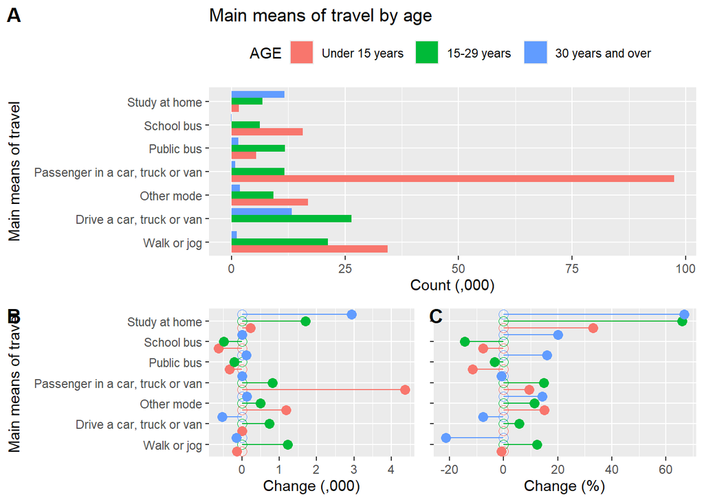

# 7 Fitting models:

The census data represents a count of responses to the census question “What was your main means of travel to education?”. The question has been asked in the 2018 and 2023 census questionnaires and provides for 10 possible responses, with that can be summarised across several independent variables: Age, Educational institution address, Gender, and Census Year. Each of these independent variables can be used as a predictor in a regression model, either individually or in combination.

- mutual independence: variables are independent of each other

$$ln(\lambda)= \beta_0 + \sum \beta_i x_i, y \sim \text{pois}(\lambda)$$

[output not shown]

[output cut: 19 more lines]

[output not shown]

[output not shown]

### 7.0.1 Fit a model with no interaction

This model includes all predictors, with no interaction between predictors. This model considers the effect of each predictor on the count

### 7.0.3 Interaction between Age, means of travel and Gender, means of travel

This model ignores the location of educational institute and looks at the interaction between Age and Main means of travel to education and the interaction between Gender and Main means of travel to education.

### 7.0.4 Interaction between Year Age, means of travel and Year Gender, means of travel

This model ignores the location of educational institute and looks at the three way interaction between Year Age and Main means of travel to education and the three way interaction interaction between Year Gender and Main means of travel to education.

- reduce the number of cells in our table by summarising some factors (e.g. summarise data along the “Gender” and “location of educational institution” dimensions)

### 7.0.5 interaction between Age and Main means of travel

This model considers the interaction between Main means of travel and age group

### 7.0.6 Model: $\log(\text{Count}) = \lambda_{year} + \lambda_{tvl}$

Fitting the model that has the “count” of responses as the response variable and “Census Year” and “Main means of travel to education” as the predictor variables shows that all responses are significant.

```
##
## Call:
## glm(formula = VALUE ~ YEAR + TED, family = "poisson", data = tvl_to_ed_rc)
##
## Coefficients:
##                                      Estimate Std. Error z value Pr(>|z|)
## (Intercept)                          7.449250   0.001636  4552.7   <2e-16 ***
## YEAR2023                            -0.371525   0.001309  -283.9   <2e-16 ***
## TEDBicycle                          -1.678556   0.003769  -445.4   <2e-16 ***
## TEDDrive a car, truck or van        -0.580028   0.002495  -232.5   <2e-16 ***
## TEDFerry                            -5.084217   0.019052  -266.9   <2e-16 ***
## TEDOther                            -2.695017   0.005943  -453.5   <2e-16 ***
## TEDPassenger in a car, truck or van  0.733657   0.001819   403.4   <2e-16 ***
## TEDPublic bus                       -1.001611   0.002884  -347.3   <2e-16 ***
## TEDSchool bus                       -0.691292   0.002587  -267.2   <2e-16 ***
## TEDStudy at home                    -1.022879   0.002907  -351.9   <2e-16 ***
## TEDTrain                            -2.423897   0.005240  -462.6   <2e-16 ***
## ---
## Signif. codes:  0 '***' 0.001 '**' 0.01 '*' 0.05 '.' 0.1 ' ' 1
##
## (Dispersion parameter for poisson family taken to be 1)
##
##     Null deviance: 10193690  on 3199  degrees of freedom
## Residual deviance:  7631200  on 3189  degrees of freedom
##   (640 observations deleted due to missingness)
## AIC: 7645238
##
## Number of Fisher Scoring iterations: 8
```

```
##                         (Intercept) TEDPassenger in a car, truck or van
##                             1718.57                                2.08
##                            YEAR2023        TEDDrive a car, truck or van
##                                0.69                                0.56
##                       TEDSchool bus                       TEDPublic bus
##                                0.50                                0.37
##                    TEDStudy at home                          TEDBicycle
##                                0.36                                0.19
##                            TEDTrain                            TEDOther
##                                0.09                                0.07
##                            TEDFerry
##                                0.01
```

However, this model does not adequately fit the data, so we consider further consolidating the travel to education data by reducing the number of levels. We can aggregate by “Private vehicle” (“Passenger in…” or “Drive a car, truck or van”), “Public transport” (“Public bus”, “School bus”, “Train”, “Ferry”, “Other”), “Study at home”, “Self-powered” (“Bicycle” and “Walk or jog”).